# 70-467 Machine Learning for Business Analytics

Class 1: Introduction

Professor: Andrés Castaño Zuluaga

24 August 2026 · CMU-Q

## Bio

- Assistant Teaching Professor of Economics and Analytics
- Ph.D. in Regional Economics from Cornell
- Teaching
  - At CMU since 2023
  - Principles of Macroeconomics; End-to-End Business Analytics; Emerging Markets; MLBA (this semester)
- Research
  - Regional economics, labor and development economics
  - Diversification in natural-resource economies, migration economics, applied econometrics

## Tell us who you are

1 Name What should we call you?

2 Major What are you studying?

3 One thing you want from this class One sentence is enough.

## Outline for today

- What’s MLBA?
- Why MLBA, and why in the era of AI
- Syllabus overview
- A first glimpse into MLBA

## What’s MLBA?

## What’s Machine Learning for Business Analytics

Data

Models

Decisions

Prediction  
Classification  
Machine Learning

Prescription  
Optimization

## Example: Customer profiling

A drugstore chain in Qatar. Six million baskets, half a million customers. They need to see how people shop, and where products should sit across the store.

How would you approach this?

- What is the decision the chain actually has to make?
- Is there a target to predict, or are you looking for structure in the baskets?
- What would a useful answer look like: a number, a grouping, a map of products?

## Solution: Clustering (many X features, no Y outcome)

Solution

Twenty undirected clusters. No target Y.

Products that land in the same cluster go on the same shelf.

Apte, Liu, Pednault, and Smyth. 2002. *Communications of the ACM* 45(8): 49–53.

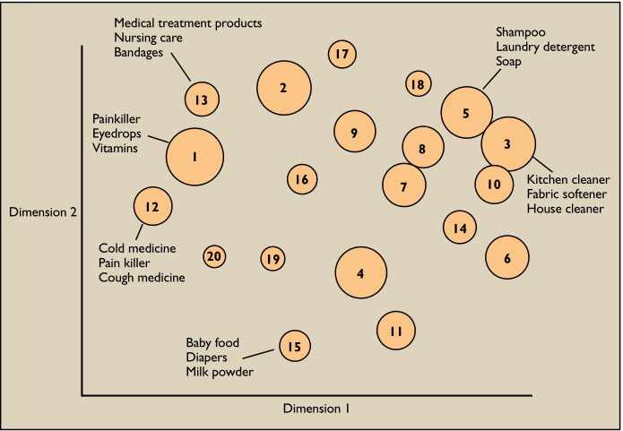

## What we will learn: general principles

- Classification vs. regression
- Supervised learning vs. unsupervised learning
- In-sample vs. out-of-sample
- Underfitting vs. overfitting
- Cross-validation
- Regularization
- Dealing with different types of data

## What we will learn: specific models

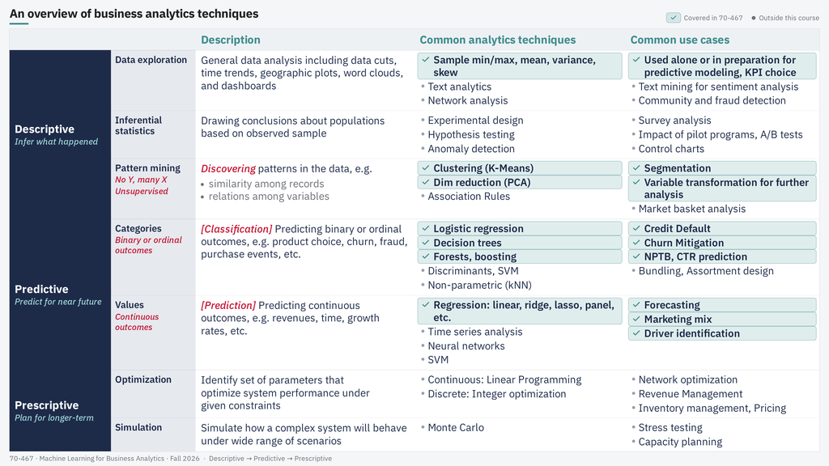

## Why MLBA in the era of AI?

## Why learn MLBA in the era of AI?

01

Adoption is widespread across organizations; productive gains yet to be found in aggregate.

Most organizations use AI. Few have added value!.

02

The market is looking for AI-complementary skills.

AI skills carry a wage premium; AI-exposed firms seem to grow productivity and hiring faster.

03

AI tools are partners, not substitutes, for learning, verification, and judgment.

Without proper understanding, model answers can hide weak models, bias, overfitting, and poor judgement.

## Adoption is widespread.

GenAI is spreading faster than the internet or the PC

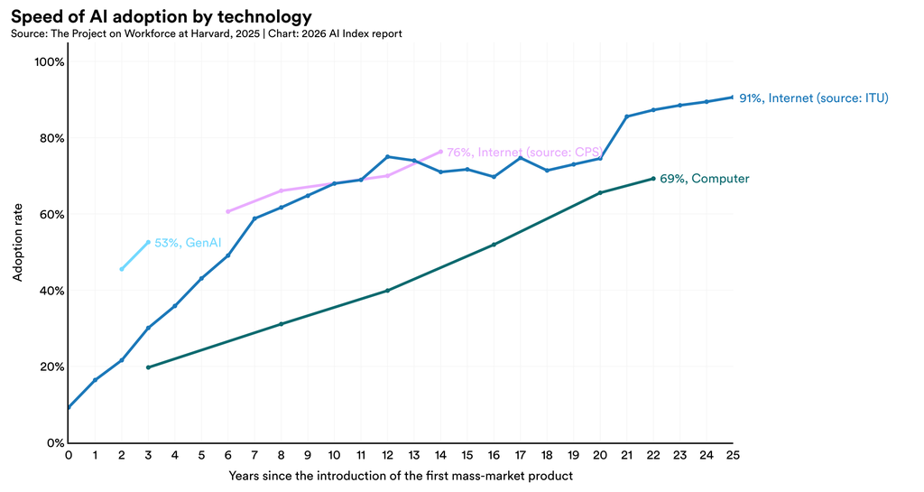

Source: Project on Workforce at Harvard, 2025. Chart: Stanford HAI, 2026 AI Index Report, Economy.

## Adoption is widespread.

GenAI broke a six-year stall — 88% of organizations now use AI

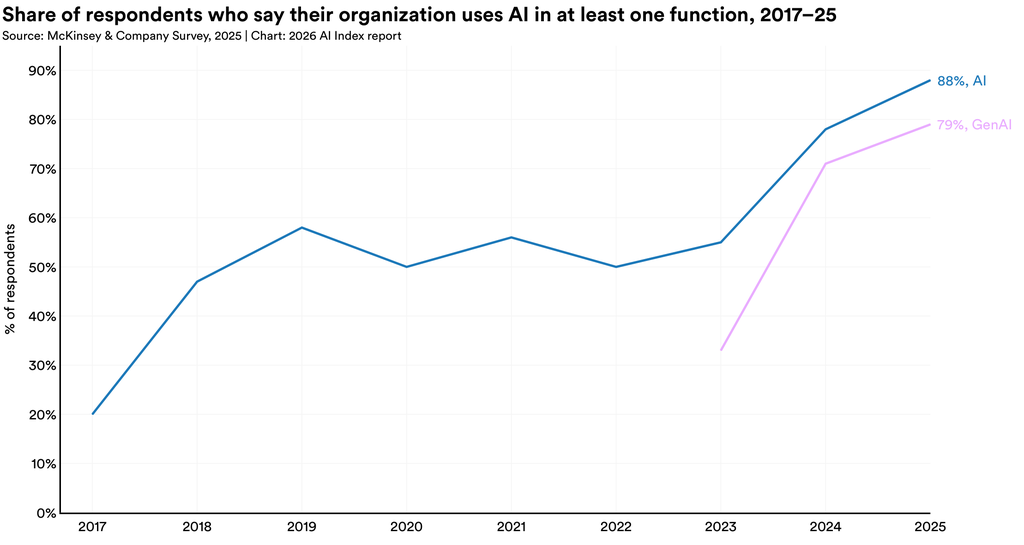

Source: McKinsey, The state of AI in 2025 (survey). 88% also in Stanford HAI, 2026 AI Index, Economy.

## The market is looking for AI-complementary skills.

AI hiring exploded, and the fastest-growing skills are operational

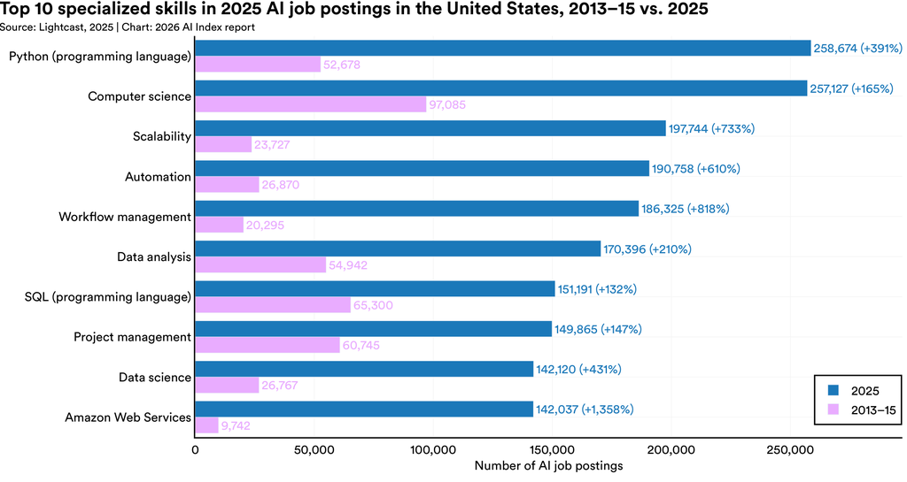

Source: Lightcast, 2025. Chart: Stanford HAI, 2026 AI Index Report.

## The market is looking for AI-complementary skills.

AI jobs are spreading beyond tech, every US sector grew in 2025

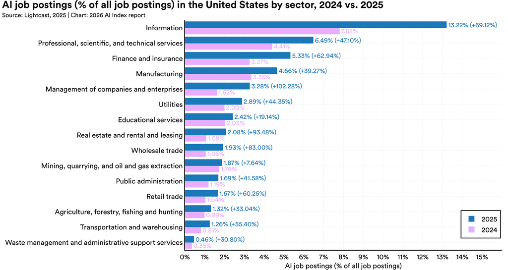

Source: Lightcast, 2025. Chart: Stanford HAI, 2026 AI Index Report.

## AI tools are partners, not substitutes.

Automation is cutting entry-level jobs; augmentation is not

[figure not shown]

Brynjolfsson, Chandar, and Chen, 2026 (rev.). Canaries in the Coal Mine. Stanford DEL / ADP. Not causal; US payroll panel.

## AI tools are partners, not substitutes.

Most students use AI weekly: to learn, not just to finish faster

[figure not shown]

[figure not shown]

Lumina Foundation–Gallup, 2026 State of Higher Education (fielded Oct 2–31, 2025). U.S. opt-in panel, not this room.

## AI tools are partners, not substitutes.

AI raises homework scores, and lowers exam scores

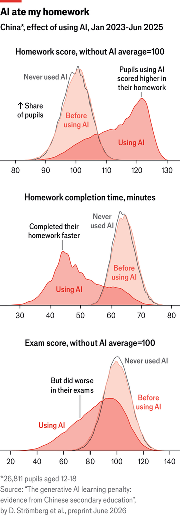

Strömberg, Lei, and Wu. 2026. CEPR DP 21577. China, grades 7–12, n=26,811. Not this classroom.

## AI and jobs: two predictions

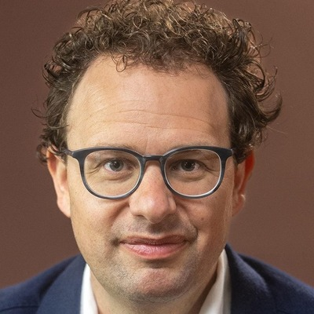

Dario Amodei · CEO Anthropic

AI could eliminate half of entry-level white-collar jobs within 1–5 years… unemployment possibly 10–20%.

Cognitive substitute.

Speed + breadth make adaptation unusually painful.

Axios, 28 May 2025. “The Adolescence of Technology,” Jan 2026.

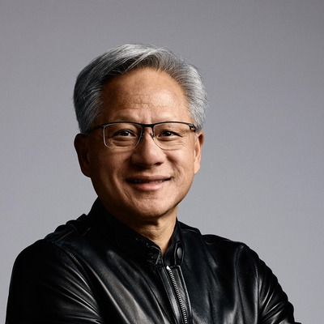

Jensen Huang · CEO NVIDIA

You’re not going to lose your job to an AI, but you’re going to lose your job to someone who uses AI.

Tasks are automated; the purpose of the job expands.

Productivity multiplies demand → more jobs and new occupations.

Milken Institute, 6 May 2025. CNBC Make It, 28 May 2025. [Video](https://www.youtube.com/watch?v=HT8-KPAjpiA)

Which prediction do you hope is true? Which one do you expect?

What does each view ask of you as future analysts and managers?

## Main takeaways

- **Most organizations are using AI.** Very few can show it added value.
- **Firms are hiring people who can work *with* AI,** not people AI can replace.
- **The tool can help you learn.** It cannot replace understanding, checking the work, or judgment.

You’re not going to lose your job to an AI. You’re going to lose it to someone who uses AI to become more curious, to understand ideas and methods more deeply, to exercise better judgment, and to communicate technical results more effectively to people who have to act on them.

Adapted from Jensen Huang, May 2025

## Syllabus overview

## Learning resources

### Book

- ISLR, 2nd ed. — James, Witten, Hastie, Tibshirani
- Free online
- Notes point to the sections we used in class

### Notes and slides

- On the website and Canvas
- Slide PDF after class, not before
- If something does not open, email me

### R

- R and RStudio (Posit). Laptop to every lab
- Labs and homework start from a problem and scripts I provide
- Finish R Setup after today, before the first lab

### The week

- Monday and Wednesday, 2:30–3:45, CMB 1190
- First lab: **Wednesday 2 September**

## How you are graded

24% Homework 6% each. Individual. R notebook + at most six slides + a video of at most five minutes.

16% Quizzes 4% each. In class, designed for 10–15 minutes. There is no make-up for quizzes.

10% Pair Presentation About twice in the semester. 8–10 minutes and a short deck, introducing a topic in the context of a business problem.

22% Midterm Wednesday 7 October, in class, closed notes. Weeks 1–5 only.

20% Final Project Individual. Brief 28 October. Checkpoint 18 November. Presentations 30 November and 2 December. No final exam.

8% Participation & Attendance Come ready, contribute, and work in the labs.

## Office hours and AI policy

Hours

### Office hours

- Office **2160**
- Wednesdays, **5:30–6:45 pm**, in person, 15-minute slots
- Book from the syllabus or Canvas
- On Mondays, laptops are closed unless I ask you to open them for a short demonstration. On Wednesdays, laptops are required for R.

Yellow level

### AI with caution

- Homework and the project (when the assignment allows it)
- You may use AI to learn, debug, and clarify concepts
- The analysis, interpretation, and recommendation must be yours. You must run the code.

Red level

### No AI

- Quizzes and the midterm. No AI tools for any purpose on these assessments
- The oral defense of the project and the in-class Q&A also require that you can explain the work without AI in the room

If you hide AI use, or you cannot explain the work in the video, or I suspect you used AI inappropriately, I will ask you to present in person. Depending on how you handle the questions in person, the grade on that homework can go as low as 0, and you may be reported for an academic integrity violation.

## A first glimpse into MLBA

One firm. One file.

## Headquarters has a file on 400 stores.

A company that sells child car seats. 400 stores. Headquarters has a file: sales, our price, the competitor’s price, local ads, the quality of the shelf, and a few things about the neighborhood.

They are thinking about prices and ads for next quarter. Look at the rows. Sales are all over the place. Some stores charge more. Some sit next to a cheaper competitor. Some have a good shelf.

400 stores · 11 columns

```
> head(stores)
  Sales Price CompPrice Advertising ShelveLoc  US
1  9.50   120       138          11       Bad Yes
2 11.22    83       111          16      Good Yes
3 10.06    80       113          10    Medium Yes
4  7.40    97       117           4    Medium Yes
5  4.15   128       141           3       Bad  No
6 10.81    72       124          13       Bad Yes

> dim(stores)
[1] 400  11
```

Sales in thousands of units. Price and CompPrice in dollars.

## What is in the file

| Variable | What it is |
| --- | --- |
| The store |  |
| Sales | Units sold at the store (thousands) |
| Price | Our list price (dollars) |
| CompPrice | Competitor’s price at that location (dollars) |
| Advertising | Local advertising (thousands of dollars) |
| ShelveLoc | Bad / Medium / Good — the shelf, not the seat |
| The neighborhood |  |
| Income, Age, Population, Education | Income and population in thousands; Age and Education in years |
| Urban, US | Yes / No |

## How would you use this file?

1. Look at stores 1 and 5. Both have a Bad shelf. Sales are 9.50 vs 4.15. What in the file might be going on?
2. Headquarters is considering a $10 price cut. What would you want to look at in this file before you agree?
3. Does advertising move sales once price and the shelf are in the picture?
4. Could you use this file to say roughly how many units a store like this will sell next quarter? What would you have to assume?

## A regression does three jobs.

Descriptive

### How are the variables related?

Explanatory

### How does bad shelf location explain differences in sales?

Predictive

### What will be the estimated sales for next quarter?

These are three uses of a **regression**. Wednesday we write it down and fit it. We do not fit it today.

## Before Wednesday

Quiz 1 is **31 August**. First lab is **2 September**.

ISLR chapter 1, pages 1–6

What statistical learning is, with three examples: wages, the stock market, and genes.

ISLR chapter 2, pages 15–22

Why we estimate a relationship from data: to predict, or to understand.

ISLR chapter 3, pages 59–70

How we fit a regression line, and how we decide whether that line is any good.

2nd ed., James, Witten, Hastie, and Tibshirani. Free at statlearning.com. The notes will cut this to what we actually use.

## References

1. Apte, C., Liu, B., Pednault, E. P. D., and Smyth, P. 2002. “Business Applications of Data Mining.” *Communications of the ACM* 45(8): 49–53. dl.acm.org/doi/10.1145/545151.545178
2. Stanford HAI. 2026. *The 2026 AI Index Report*, Ch. 4 Economy. Charts: GenAI adoption; Lightcast skills and sectors. hai.stanford.edu/ai-index/2026-ai-index-report/economy
3. McKinsey & Company. 5 Nov 2025. “The state of AI in 2025: Agents, innovation, and transformation.” 88% of surveyed organizations use AI in at least one function. [mckinsey.com/.../the-state-of-ai](https://www.mckinsey.com/capabilities/quantumblack/our-insights/the-state-of-ai)
4. Project on Workforce at Harvard. 2025. Speed of AI adoption. Chart via Stanford HAI 2026 AI Index, Ch. 4.
5. Lightcast. 2025. AI job postings, skills and US sectors. Charts via Stanford HAI 2026 AI Index, Ch. 4.
6. Lumina Foundation–Gallup. 2026. “AI Is Routine for College Students, Despite Campus Limits.” Fielded 2–31 Oct 2025. Opt-in panel, not this room. [news.gallup.com/poll/704090](https://news.gallup.com/poll/704090/routine-college-students-despite-campus-limits.aspx)
7. Brynjolfsson, E., Chandar, B., and Chen, R. 2025, rev. Aug 2026. “Canaries in the Coal Mine?” Stanford Digital Economy Lab / ADP. Not causal. [digitaleconomy.stanford.edu](https://digitaleconomy.stanford.edu/publications/canaries-in-the-coal-mine/)
8. Strömberg, D., Lei, V., and Wu, Y. 2026. “The Generative AI Learning Penalty.” CEPR DP 21577. China, grades 7–12, n = 26,811. Not this classroom. cepr.org/publications/dp21577
9. Amodei, D. 28 May 2025. Interview in Axios, “Behind the Curtain: A white-collar bloodbath.” [axios.com/2025/05/28/...](https://www.axios.com/2025/05/28/ai-jobs-white-collar-unemployment-anthropic)
10. Amodei, D. Jan 2026. “The Adolescence of Technology.” darioamodei.com/essay/the-adolescence-of-technology
11. Huang, J. 6 May 2025. Milken Institute Global Conference. Video: youtube.com/watch?v=HT8-KPAjpiA. Reported in CNBC Make It, 28 May 2025. [cnbc.com/2025/05/28/...](https://www.cnbc.com/2025/05/28/nvidia-ceo-jensen-huang-youll-lose-your-job-to-somebody-who-uses-ai.html)
12. James, G., Witten, D., Hastie, T., and Tibshirani, R. 2021. *An Introduction to Statistical Learning with Applications in R*. 2nd ed. Carseats file and Wednesday readings. [statlearning.com](https://www.statlearning.com/)